# 03 Session 3: Maps as Processes

# Practice questions

Answer the following questions:

1. What is a Geographic Information System?
2. What distinguishes a statistical map from other types of mapping techniques?
3. What is a null landscape?

# Learning objectives

In this activity, you will:

1. Learn about stochastic processes.
2. Simulate landscapes using various types of processes.
3. Discuss the difference between random and non-random landscapes.
4. Think about ways to decide whether a landscape is random.

# Suggested reading

O’Sullivan D and Unwin D (2010) Geographic Information Analysis, 2nd Edition, Chapter 4. John Wiley & Sons: New Jersey.

# Preliminaries

For this activity you will need the following:

- This R markdown notebook.

It is good practice to clear the working space to make sure that you do not have extraneous items there when you begin your work. The command in R to clear the workspace is `rm` (for “remove”), followed by a list of items to be removed. To clear the workspace from *all* objects, do the following:

```r
rm(list = ls())
```

Note that `ls()` lists all objects currently on the worspace.

Load the libraries you will use in this activity:

```r
library(tidyverse)
```

In the practice that preceded this activity, you learned how to simulate null landscapes and spatial processes. In this activity, the concept of a *stochastic process* is introduced.

Some processes are *random*, such as the ones used in the practice to create *null landscapes*. These processes take values with some probability, but cannot be predicted with any certainty.

Let’s illustrate using again a unit square:

```r
coords <- expand.grid(x = seq(from = 0, to = 1, by = 0.05), y = seq(from = 0, to = 1, by = 0.05))
```

Here is an example of a random pattern of events:

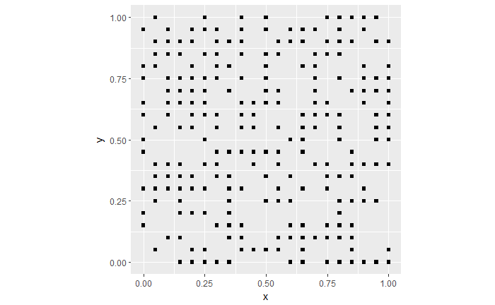

```r
events <- rbinom(n = nrow(coords), size = 1, prob = 0.5)
null_pattern <- data.frame(coords, events)
ggplot() +
  geom_point(data = subset(null_pattern, events == 1), aes(x = x, y = y), shape = 15) +
  coord_fixed()
```

A *systematic* or *deterministic* process is one that contains no elements of randomness, and can therefore be predicted with complete certainty. For instance (note the use of `xlim` to set the extent of x axis in the plot):

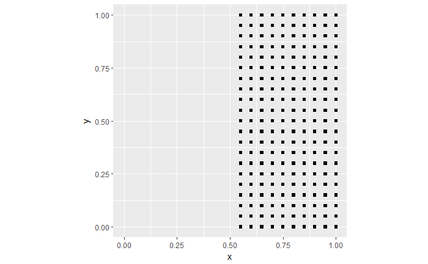

```r
deterministic_point_pattern <- coords
deterministic_point_pattern <- mutate(deterministic_point_pattern, events = round(x))
ggplot() +
  geom_point(data = subset(deterministic_point_pattern, events == 1), aes(x = x, y = y), shape = 15) +
  xlim(0, 1) +
  coord_fixed()
```

In the process above, I used the function `round()` and the coordinate `x`. The function gives a value of one for all points with x > 0.5, and a value of zero to all points with x <= 0.5. The pattern is fully deterministic: if I know the value of the x coordinate I can predict whether an event will be present.

A *stochastic process*, on the other hand, is a process that is neither fully random or deterministic, but rather a combination of the two. Let’s illustrate:

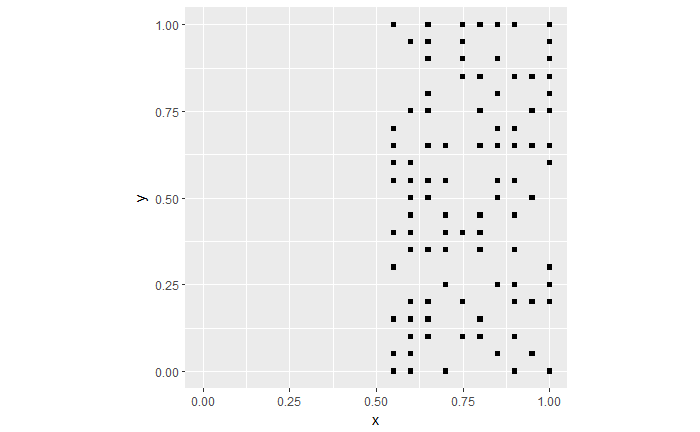

```r
stochastic_point_pattern <- coords
stochastic_point_pattern <-
  mutate(stochastic_point_pattern,
         events = round(x) - round(x) * rbinom(n = nrow(coords), size = 1, prob = 0.5))
ggplot() +
  geom_point(data = subset(stochastic_point_pattern, events == 1), aes(x = x, y = y), shape = 15) +
  xlim(0, 1) +
  coord_fixed()
```

The process above has a deterministic component (the probability of an event is zero if x <= 0.5), and a random component (the probability of a coordinate being an event is 0.5 when x > 0.5).

# Activity

1. Simulate and plot a landscape using a random, stochastic, or deterministic process. It is your choice whether to simulate a point pattern or a continuous variable.
2. Share the map with a fellow student, and ask them to guess whether the map is random or non-random.
3. Repeat 1 and 2 a few times.
4. Propose one or more ways to decide whether a landscape is random, and explain your reasoning. The approach does not need to be the same for point patterns and continuous variables!